# Messaging Experiment

CoreyJackson

11/24/2016

The analysis for the messaging experiment. On October 12th 2016 four types of messages were sent to users with registered accounts highlighting one of four motivational aspects of participation - altrusim, learning, contribution, and social proof (Table below). Overall, the message response Volunteers who received the altruism message were less likely to click the link to Gravity Spy than those who received other messages at significance p = .05 level; but no statistically significant difference was found among the other three message conditions. The analysis below examines the long-term impacts of the messaging on the number of classifications volunteers contributed one day, two days, one week, and one month (only data until Oct 20th) after the messages were sent.

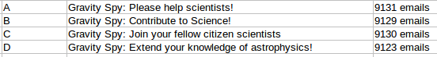

Since the data are non-normal, the experiment was analyzed using the non-parametric Kruskal Wallis One Way Anova by Ranks Test.

Some features of the data:

- Users who contributed prior to the experiment messaging were removed

## One Day After Messaging

The amount of annotations submitted between 2016-10-12 and 2016-10-13

```r
OneStats
```

```
##                 cohort2 Users Total      Mean Median        SD        Var
## 1 Contribute to Science   157  6550  41.71975   13.0  96.21536   9257.395
## 2      Expand Knowledge   154 11488  74.59740   15.0 218.98248  47953.327
## 3       Help Scientists   182 10217  56.13736   15.0 207.84388  43199.080
## 4            Join Peers   136 15702 115.45588   15.5 607.67881 369273.539
```

```r
kruskal.test(Classifications~cohort, data=OneDayClassAfter)
```

```
##
##  Kruskal-Wallis rank sum test
##
## data:  Classifications by cohort
## Kruskal-Wallis chi-squared = 2.3154, df = 3, p-value = 0.5096
```

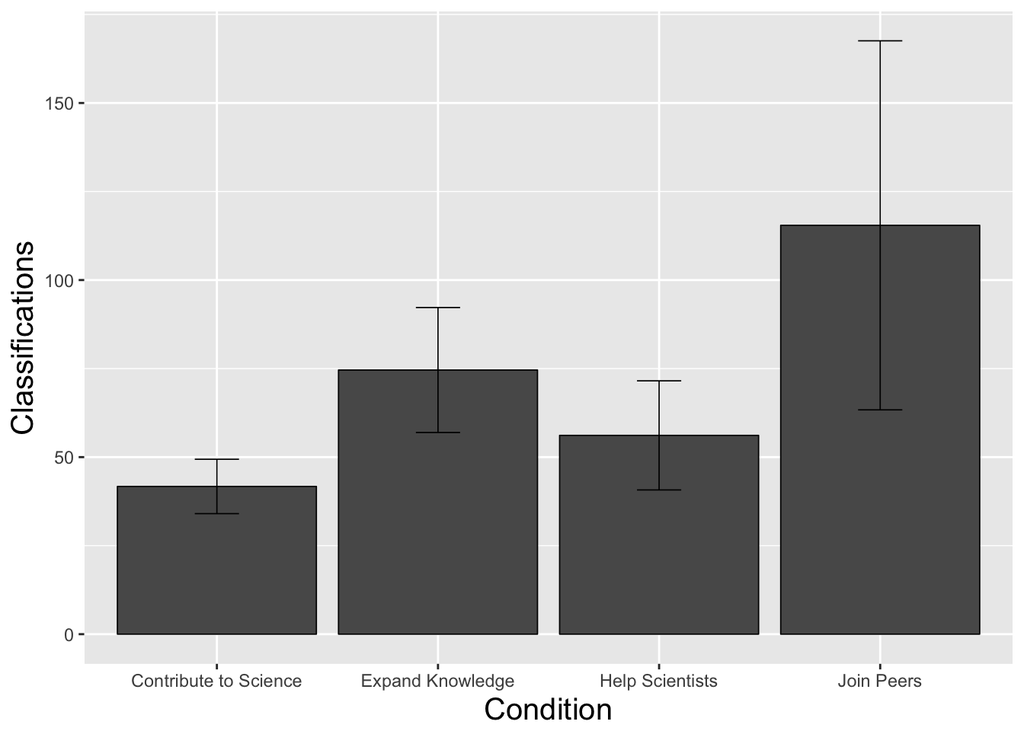

```r
a
```

## Two Days After Messaging

The amount of annotations submitted between 2016-10-12 and 2016-10-14

```r
TwoStats
```

```
##                 cohort2 Users Total      Mean Median       SD       Var
## 1 Contribute to Science   192 11192  58.29167     15 124.9875  15621.88
## 2      Expand Knowledge   189 15517  82.10053     17 225.7447  50960.65
## 3       Help Scientists   223 15203  68.17489     17 249.8906  62445.33
## 4            Join Peers   165 19488 118.10909     21 554.5268 307499.93
```

```r
kruskal.test(Classifications~cohort, data=TwoDayClassAfter)
```

```
##
##  Kruskal-Wallis rank sum test
##
## data:  Classifications by cohort
## Kruskal-Wallis chi-squared = 2.9448, df = 3, p-value = 0.4002
```

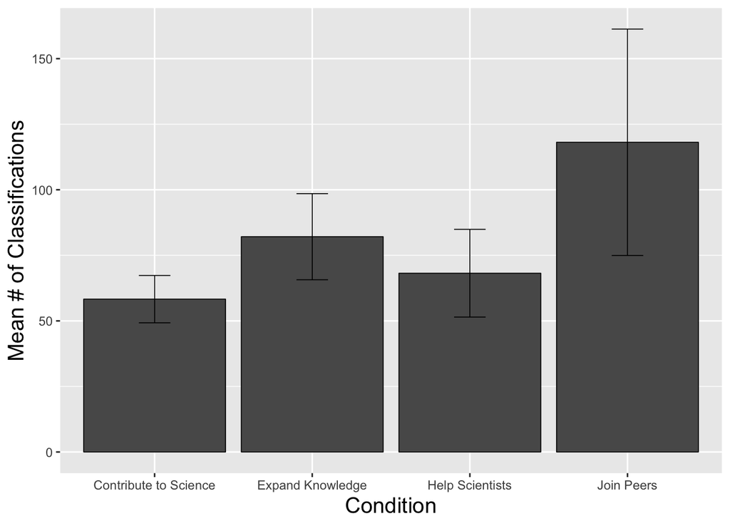

```r
b
```

## Week After Messaging

The amount of annotations submitted between 2016-10-12 and 2016-10-19

```r
WeekStats
```

```
##   cohort Users Total     Mean Median       SD       Var
## 1      A   263 29866 113.5589     21 361.2821 130524.74
## 2      B   239 28626 119.7741     20 315.6947  99663.15
## 3      C   208 30749 147.8317     31 517.7614 268076.87
## 4      D   237 32197 135.8523     25 425.7483 181261.59
```

```r
kruskal.test(Classifications~cohort, data=WeekClassAfter)
```

```
##
##  Kruskal-Wallis rank sum test
##
## data:  Classifications by cohort
## Kruskal-Wallis chi-squared = 2.662, df = 3, p-value = 0.4467
```

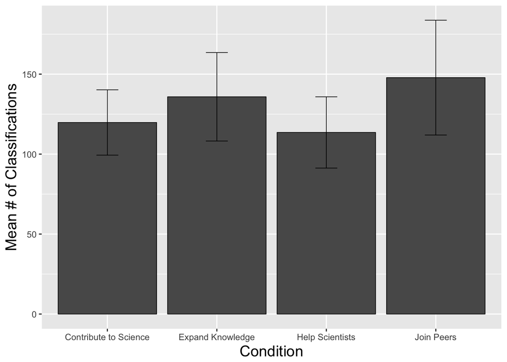

```r
c
```

## Month After Messaging

The amount of annotations submitted between 2016-10-12 and 2016-10-20

```r
MonthStats
```

```
##   cohort Users Total     Mean Median       SD      Var
## 1      A   271 32197 118.8081     23 372.9274 139074.8
## 2      B   251 31835 126.8327     21 323.0138 104337.9
## 3      C   214 32653 152.5841     32 515.0066 265231.8
## 4      D   243 34237 140.8930     25 438.6181 192385.9
```

```r
kruskal.test(Classifications~cohort, data=MonthClassAfter)
```

```
##
##  Kruskal-Wallis rank sum test
##
## data:  Classifications by cohort
## Kruskal-Wallis chi-squared = 2.478, df = 3, p-value = 0.4793
```

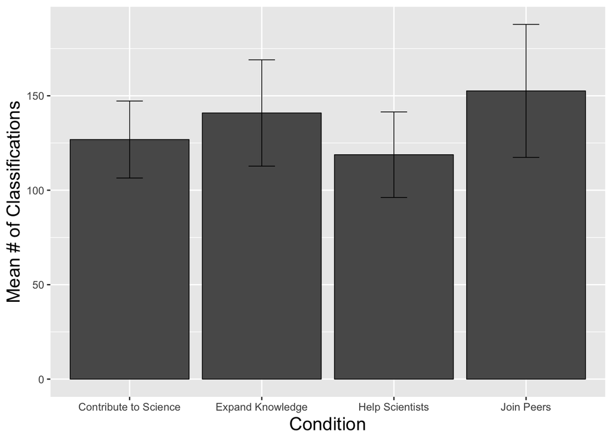

```r
d
```

## Overall Findings

- Impact of Messaging on getting people to contribute more annotations
  - There are no significant differences in annotations submitted during any time frame.